# Моментум-стратегии и reality check Китай (данные с нулями)

> Количество исследумых компаний – **284**

> Период отслеживания менялся от **1** до **12** месяцев

> Период ожидания менялся от **0** до **8** недель

> Период инвестирования менялся от **1** до **12** месяцев

## 1. Моментум стратегии при равных весах. Ранжирование по средней доходности (бенчмарк 6% годовых - только для reality check)

> Всего было рассмотрено **5184** стратегий

#### **Таблица 1. Все стратегии**

|  | mean | t | p-value | hist_per | moment_per | invest_per | percent | Amount_of_negative |
| --- | --- | --- | --- | --- | --- | --- | --- | --- |
| 1 | 0.002909 | 0.97111 | 0.334249 | 4 | 0 | 4 | 0.5 | 40 |
| 2 | 0.003206 | 1.371151 | 0.173937 | 4 | 0 | 8 | 0.5 | 42 |
| 3 | 0.005894 | 3.057601 | 0.002983 | 4 | 0 | 12 | 0.5 | 43 |
| 4 | 0.00658 | 3.802018 | 0.000269 | 4 | 0 | 16 | 0.5 | 38 |
| 5 | 0.006524 | 3.484577 | 0.000782 | 4 | 0 | 20 | 0.5 | 38 |
| 6 | 0.005303 | 2.816813 | 0.006029 | 4 | 0 | 24 | 0.5 | 38 |
| 7 | 0.004006 | 2.044542 | 0.043994 | 4 | 0 | 28 | 0.5 | 31 |
| 8 | 0.005657 | 3.35254 | 0.001197 | 4 | 0 | 32 | 0.5 | 32 |
| 9 | 0.006496 | 3.999533 | 0.000135 | 4 | 0 | 36 | 0.5 | 28 |
| 10 | 0.005925 | 3.679155 | 0.00041 | 4 | 0 | 40 | 0.5 | 31 |

[output cut: 5174 more lines]

#### **Рисунок 1.**

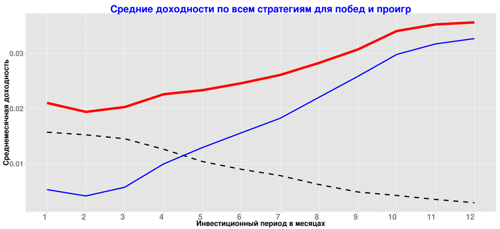

#### **Таблица 2. Агрегированные по всем стратегиям доходности победителей и проигравших**

|  | invest.per | aggr.winner | aggr.loser | delta |
| --- | --- | --- | --- | --- |
| 1 | 1 | 0.021 | 0.0053 | 0.0157 |
| 2 | 2 | 0.0194 | 0.0042 | 0.0152 |
| 3 | 3 | 0.0203 | 0.0057 | 0.0145 |
| 4 | 4 | 0.0226 | 0.01 | 0.0126 |
| 5 | 5 | 0.0233 | 0.0129 | 0.0104 |
| 6 | 6 | 0.0246 | 0.0156 | 0.009 |
| 7 | 7 | 0.0261 | 0.0182 | 0.0078 |
| 8 | 8 | 0.0283 | 0.022 | 0.0062 |
| 9 | 9 | 0.0307 | 0.0258 | 0.0049 |
| 10 | 10 | 0.0341 | 0.0298 | 0.0042 |

[output cut: 2 more lines]

> Лучшая по средней доходности стратегия дает среднемесячную доходность **3.66** **%** и имеет параметры: период отбора – **11** месяцев, период ожидания – **5** недель, период инвестирования – **1** месяцев, процентиль – **0.1**

> Bootstrap p-value равен **0.104**

> Всего портфелей у лучшей стратегии – **86** Количество отрицательных доходностей у лучшей стратегии – **32** ( **37.21%** )

#### **Рисунок 2.**

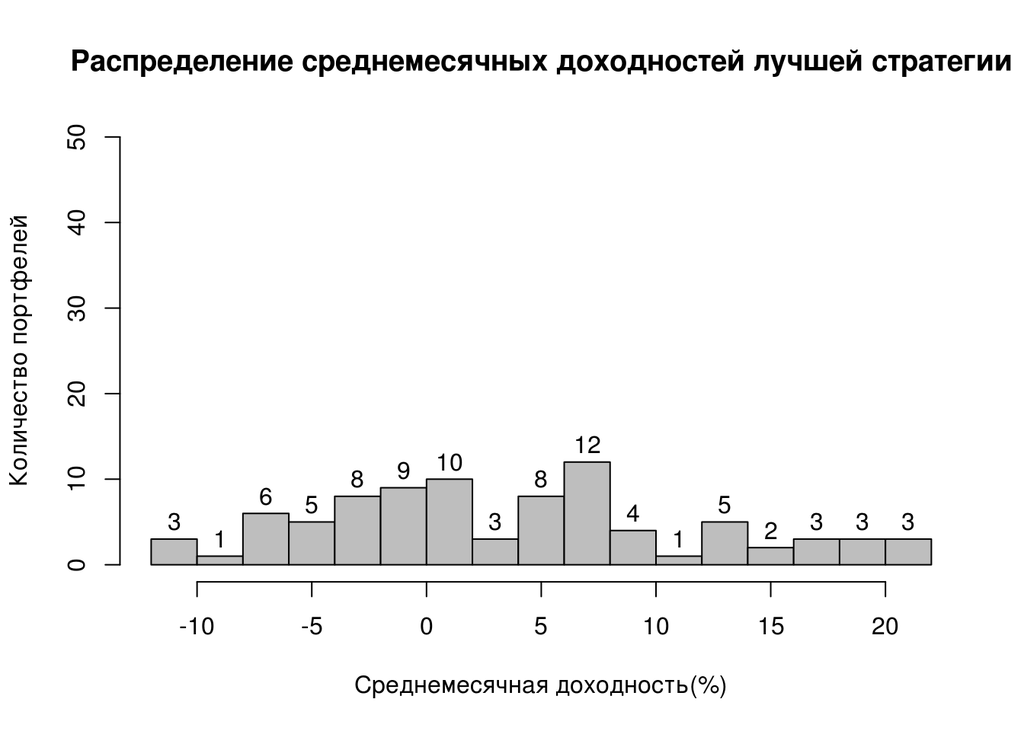

#### **Рисунок 3. (вертикальные пунктирные линии - начало нового года)**

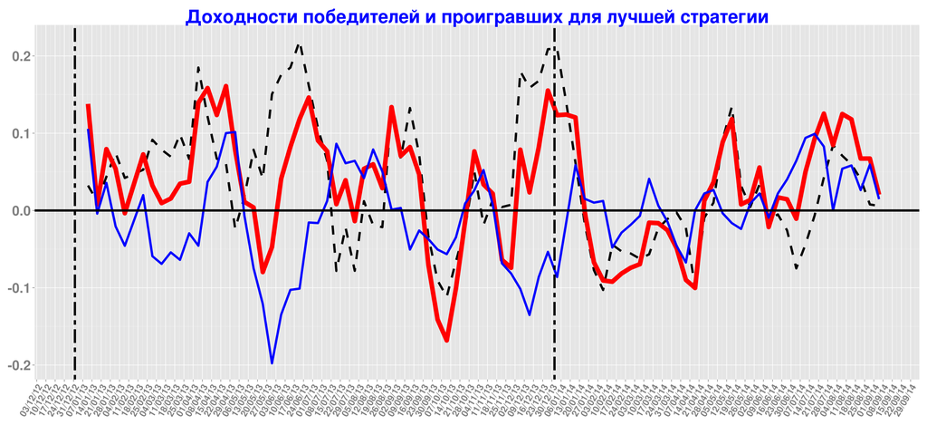

#### **Таблица 3. Доходности победителей и проигравших для лучшей стратегии**

|  | date | Win_portf | Los_portf | Win_Los |
| --- | --- | --- | --- | --- |
| 1 | 2013-01-11 | 0.138 | 0.1057 | 0.0323 |
| 2 | 2013-01-18 | 0.0077 | -0.0041 | 0.0118 |
| 3 | 2013-01-25 | 0.0794 | 0.0358 | 0.0436 |
| 4 | 2013-02-01 | 0.054 | -0.0206 | 0.0746 |
| 5 | 2013-02-08 | -0.0035 | -0.0457 | 0.0421 |
| 6 | 2013-02-22 | 0.0726 | 0.0199 | 0.0527 |
| 7 | 2013-03-01 | 0.0324 | -0.0591 | 0.0915 |
| 8 | 2013-03-08 | 0.0096 | -0.0691 | 0.0787 |
| 9 | 2013-03-15 | 0.0155 | -0.0542 | 0.0697 |
| 10 | 2013-03-22 | 0.0346 | -0.0639 | 0.0985 |

[output cut: 76 more lines]

### **Вхождение в победителей и проигравших для лучшей стратегии**

#### **Рисунок 4.**

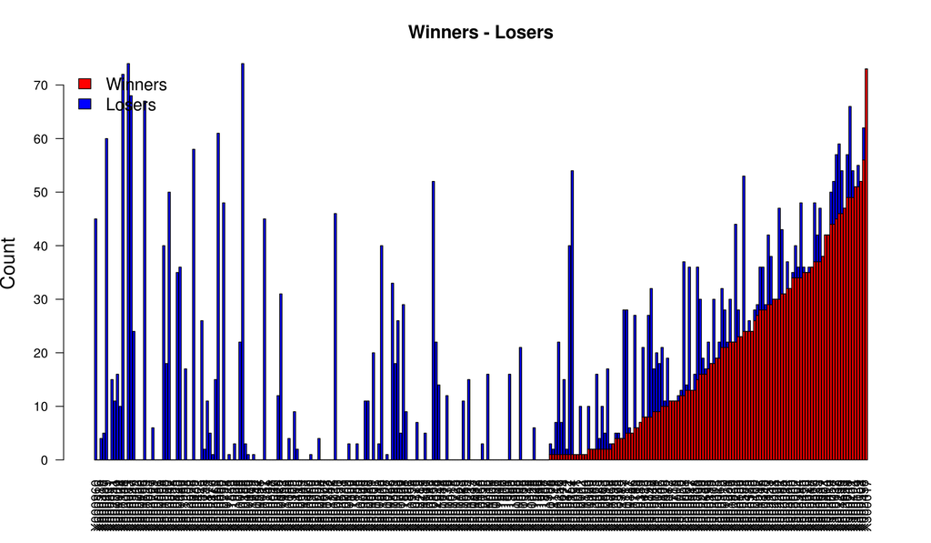

#### **Рисунок 5.**

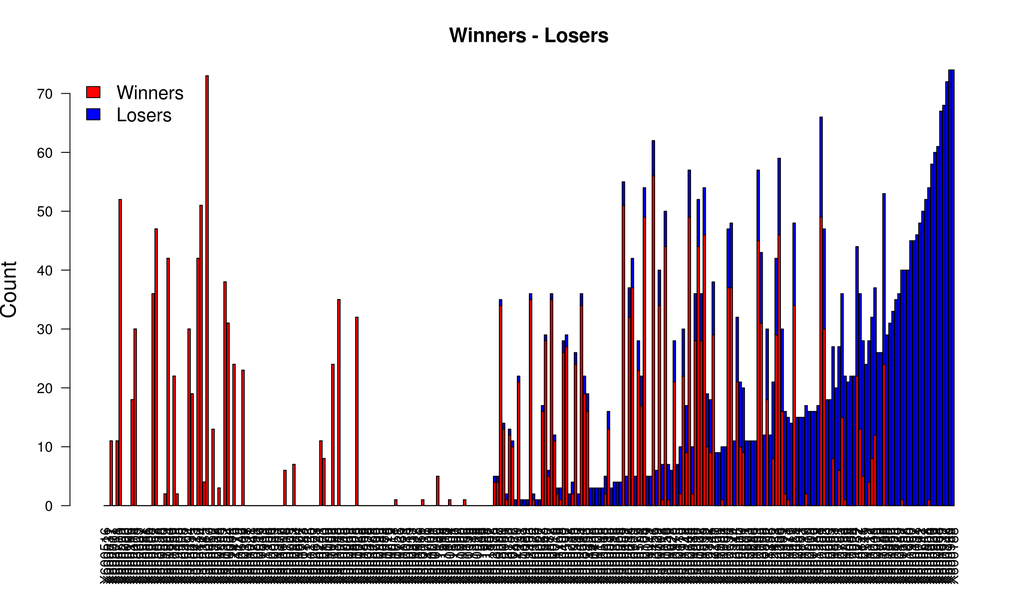

#### **Таблица 4. Вхождение компаний в победители и проигравшие для лучшей по средней доходности стратегии**

|  | Ticket | In_winners | In_losers |
| --- | --- | --- | --- |
| 1 | X002570.CH.Equity | 37 | 11 |
| 2 | X000960.CH.Equity | 0 | 45 |
| 3 | X600516.CH.Equity | 0 | 0 |
| 4 | X600108.CH.Equity | 1 | 2 |
| 5 | X600316.CH.Equity | 0 | 4 |
| 6 | X600497.CH.Equity | 0 | 5 |
| 7 | X000970.CH.Equity | 2 | 8 |
| 8 | X600809.CH.Equity | 0 | 60 |
| 9 | X600783.CH.Equity | 6 | 21 |
| 10 | X000831.CH.Equity | 0 | 0 |

[output cut: 274 more lines]

## 2. Моментум стратегии при равных весах. Ранжирование по t-статистике (бенчмарк 6% годовых - только для reality check)

> Лучшая по t-статистике стратегия дает среднемесячную доходность **2.72** **%** и имеет параметры: период отбора – **11** месяцев, период ожидания – **3** недель, период инвестирования – **4** месяцев, процентиль – **0.1**

> Bootstrap p-value равен **0.268**

> Всего портфелей у лучшей по t-статистике стратегии – **86** Количество отрицательных доходностей у лучшей по t-статистике стратегии – **18** ( **20.93%** )

#### **Рисунок 6.**

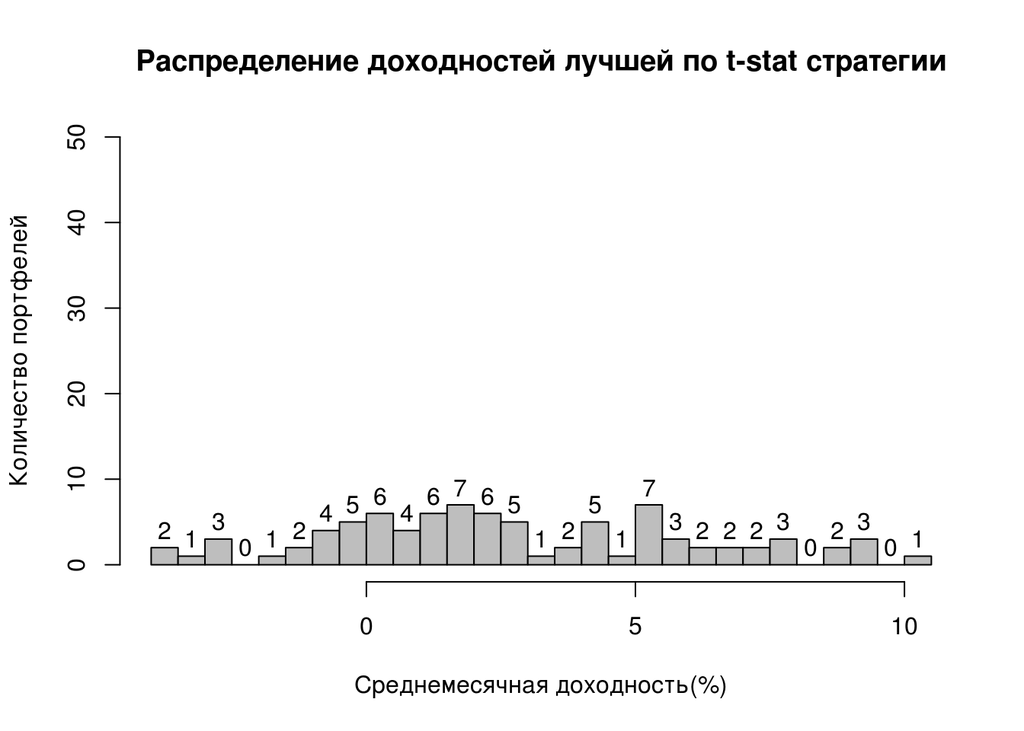

#### **Рисунок 7. (вертикальные пунктирные линии - начало нового года)**

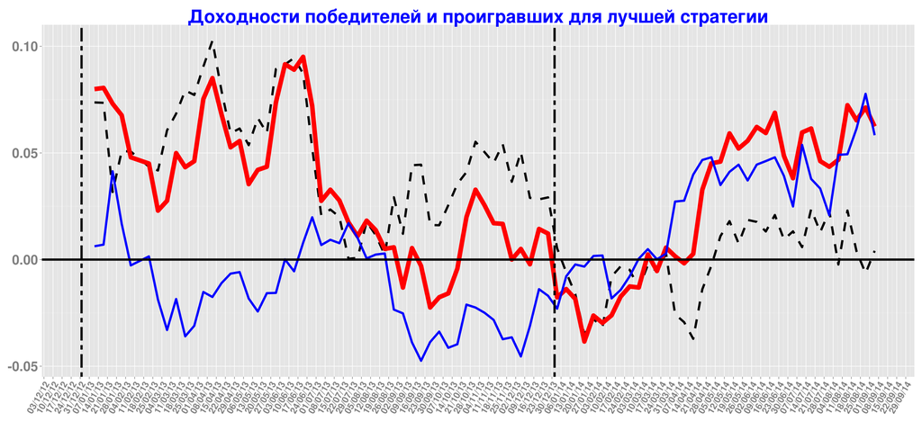

#### **Таблица 5. Доходности победителей и проигравших для лучшей стратегии**

|  | date | Win_portf | Los_portf | Win_Los |
| --- | --- | --- | --- | --- |
| 1 | 2013-01-11 | 0.0799 | 0.0062 | 0.0737 |
| 2 | 2013-01-18 | 0.0805 | 0.007 | 0.0735 |
| 3 | 2013-01-25 | 0.0731 | 0.0414 | 0.0317 |
| 4 | 2013-02-01 | 0.0676 | 0.0168 | 0.0509 |
| 5 | 2013-02-08 | 0.0479 | -0.0027 | 0.0507 |
| 6 | 2013-02-22 | 0.045 | 0.0015 | 0.0435 |
| 7 | 2013-03-01 | 0.0229 | -0.0188 | 0.0418 |
| 8 | 2013-03-08 | 0.0276 | -0.033 | 0.0606 |
| 9 | 2013-03-15 | 0.0499 | -0.0185 | 0.0684 |
| 10 | 2013-03-22 | 0.0433 | -0.036 | 0.0793 |

[output cut: 76 more lines]

### **Вхождение в победителей и проигравших для лучшей стратегии**

#### **Рисунок 8.**

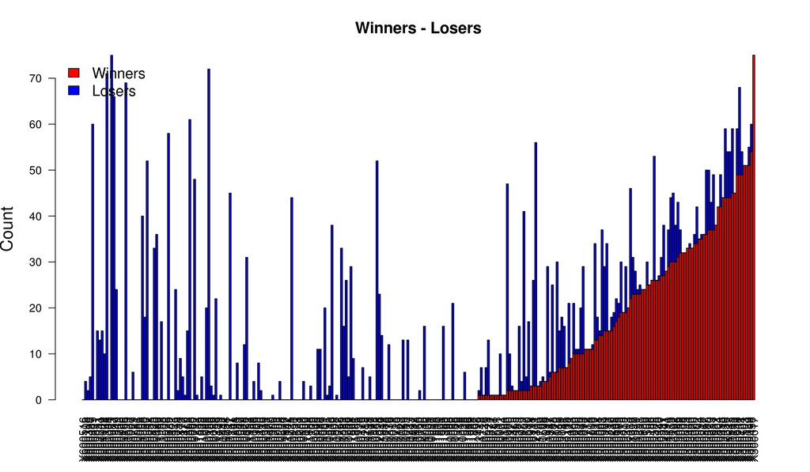

#### **Рисунок 9.**

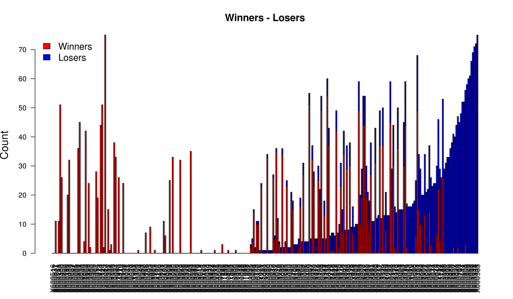

#### **Таблица 6. Вхождение компаний в победители и проигравшие для лучшей по t-статистике стратегии**

|  | Ticket | In_winners | In_losers |
| --- | --- | --- | --- |
| 1 | X002570.CH.Equity | 37 | 13 |
| 2 | X000960.CH.Equity | 2 | 45 |
| 3 | X600516.CH.Equity | 0 | 0 |
| 4 | X600108.CH.Equity | 0 | 4 |
| 5 | X600316.CH.Equity | 0 | 2 |
| 6 | X600497.CH.Equity | 0 | 5 |
| 7 | X000970.CH.Equity | 2 | 8 |
| 8 | X600809.CH.Equity | 0 | 60 |
| 9 | X600783.CH.Equity | 6 | 19 |
| 10 | X000831.CH.Equity | 0 | 0 |

[output cut: 274 more lines]